# Lecture 5: Histograms

# 5 Plot a density histogram of your data

The option freq=FALSE or prob= TRUE creates a plot based on probability densities rather than frequencies.

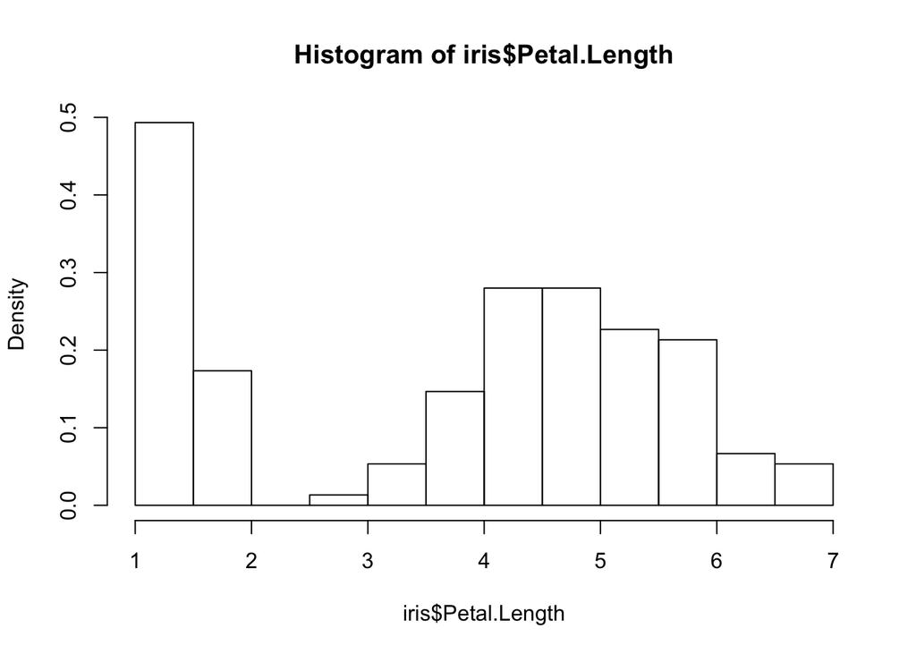

```r
# A density histogram
hist(iris$Petal.Length, freq = FALSE)

# Another way to make the same density histogram
hist(iris$Petal.Length, prob = TRUE)
```

# Histogram additional options

## 5.1 Changing the number of the bins (break OPTION)

Bin could be defined in histrogram with break option. Smaller bin result that distribution is more visible. However, to small bins result in presenting too much detail. The default value for breaks option in histogram is breaks = “Sturges”. One of the ways to calculate it is The Freedman-Diaconis rule stating h=2∗IQR∗n−1/3. In base R you could use hist(x,breaks=“FD”). The bins don’t correspond to exactly the number you put in, because of the way R runs its algorithm to break up the data.

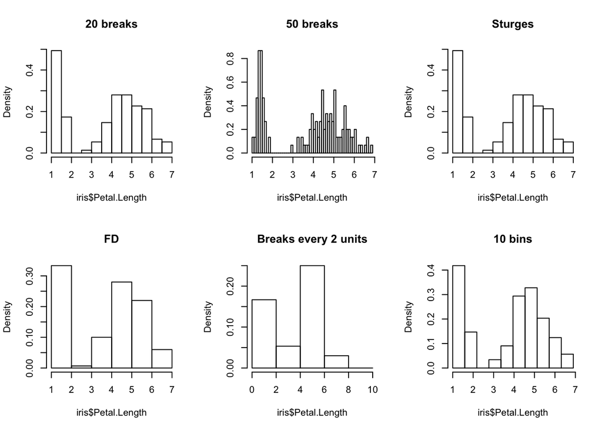

```r
# set up our figure window as a multi panel plot, with 2 rows and 3 columns.
# We have 6 plots to fit in below.
par(mfrow = c(2,3))

hist(iris$Petal.Length, freq=FALSE,  breaks = 20, main = "20 breaks")
hist(iris$Petal.Length, freq=FALSE,  breaks = 50, main = "50 breaks")
hist(iris$Petal.Length, freq=FALSE,  breaks = "Sturges", main = "Sturges")
hist(iris$Petal.Length, freq=FALSE,  breaks = "FD", main = "FD")
hist(iris$Petal.Length, freq=FALSE,  breaks = seq(from=0, to=10, by=2),
     main = "Breaks every 2 units")

# exact 10 bins - remember number of bins is n+1
hist(iris$Petal.Length, freq = FALSE,
     breaks = seq(min(iris$Petal.Length),
                  max(iris$Petal.Length),
                  length.out = 11), main = "10 bins")
```

```r
# set the figure back to a 1x1 pabel plot for subsequent plots
par(mfrow = c(1,1))
```

## 5.2 Adding Y axis limits (ylim OPTION)

If you want to specify y axis limits you can do this with *ylim* option:

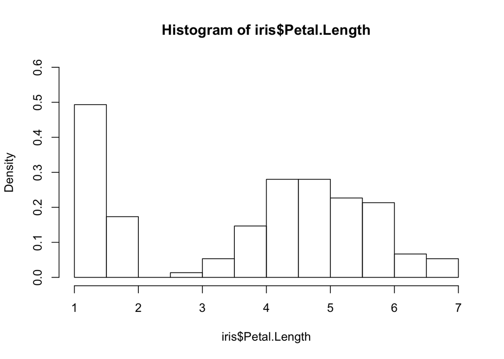

```r
hist(iris$Petal.Length, freq=FALSE, ylim=c(0, 0.6))
```

## 5.3 Main title (main OPTION)

*Main* is the plotting option to put a title on a graph

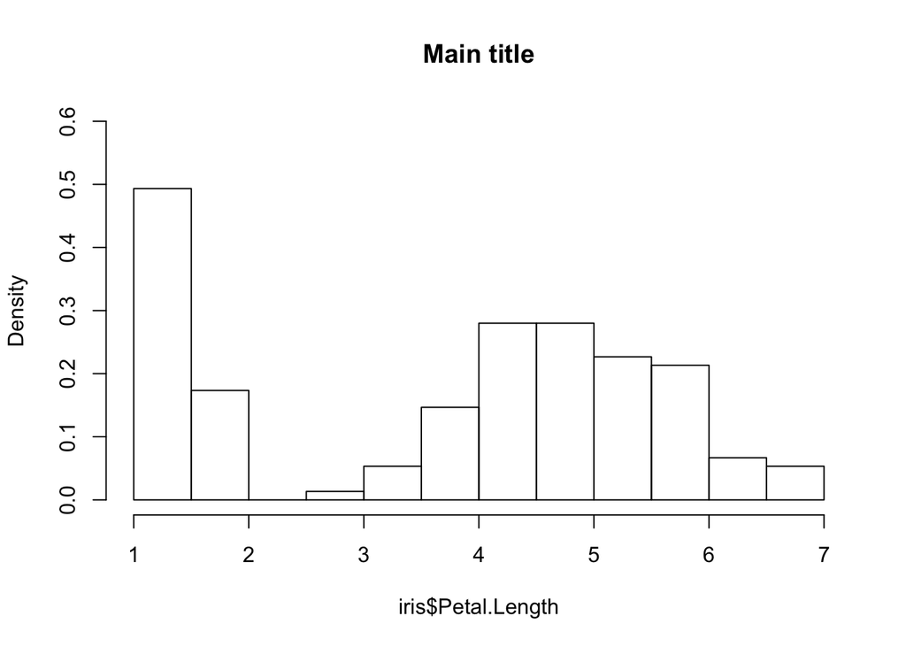

```r
# in one line
hist(iris$Petal.Length, freq=FALSE, ylim=c(0, 0.6), main="Main title")
```

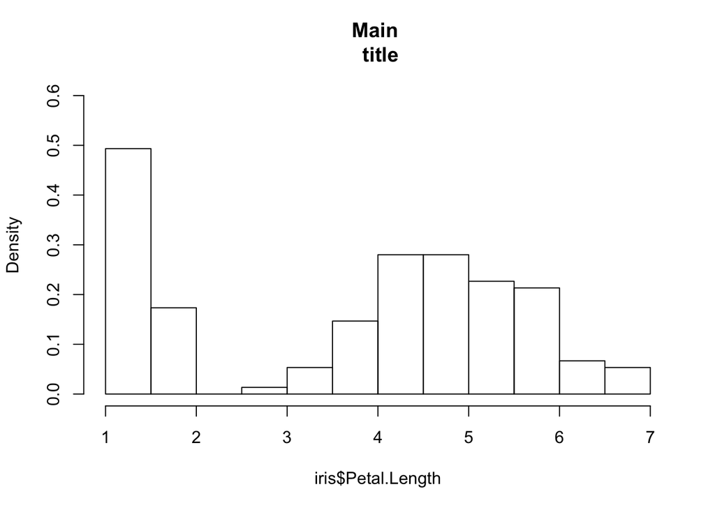

```r
# in two lines
hist(iris$Petal.Length, freq=FALSE, ylim=c(0, 0.6), main="Main \n title")
```

## 5.4 Add axis labeling (xlab, ylab OPTION)

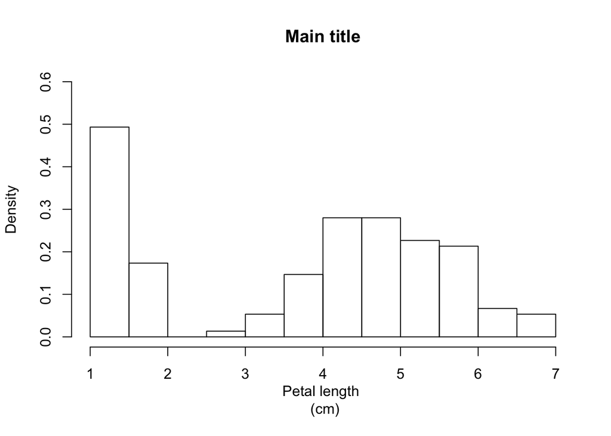

```r
hist(iris$Petal.Length, freq=FALSE, ylim=c(0, 0.6), main="Main title",
     xlab="Petal length \n (cm)", ylab="Density")
```

## 5.5 Y axis text orientation (las OPTION)

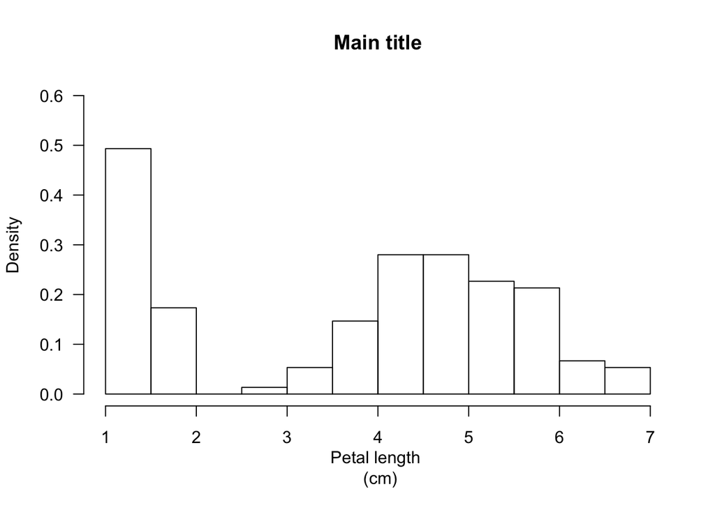

```r
hist(iris$Petal.Length, freq=FALSE, ylim=c(0, 0.6), main="Main title",
     xlab="Petal length \n (cm)", ylab="Density", las=1)
```

## 5.6 Adding a density plot

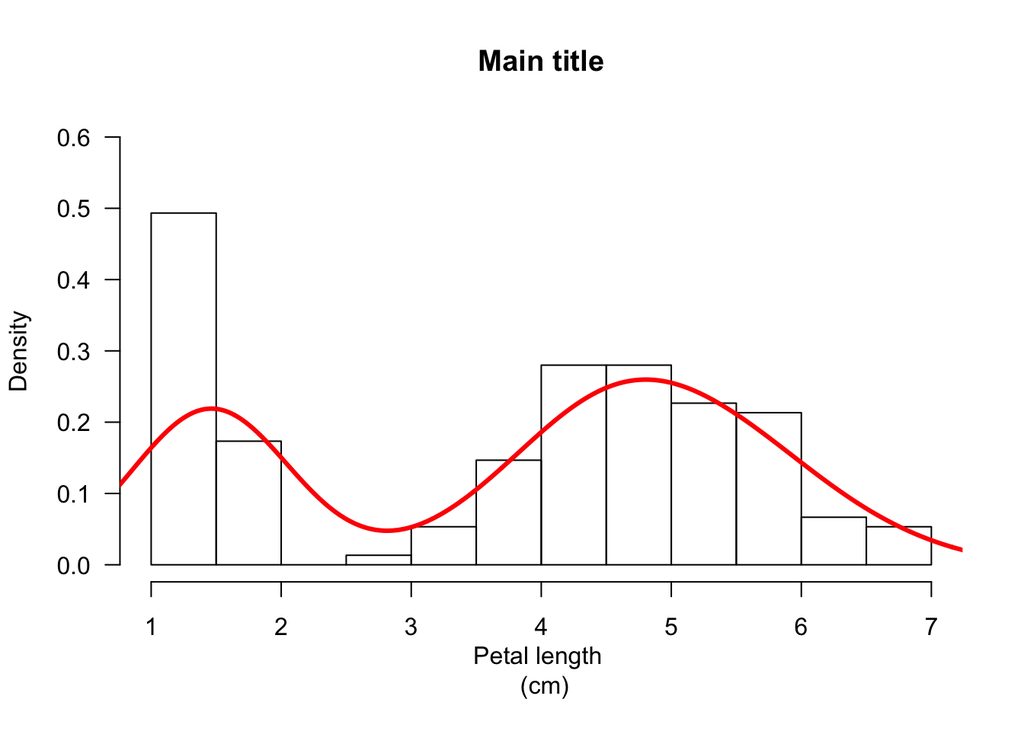

```r
hist(iris$Petal.Length, freq=FALSE, ylim=c(0, 0.6), main="Main title",
     xlab="Petal length \n (cm)", ylab="Density", las=1)

# add a line based on the density() function's interpretation
lines(density(iris$Petal.Length), col = "red", lwd = 3)
```

## 5.7 Adding normal distribution plot

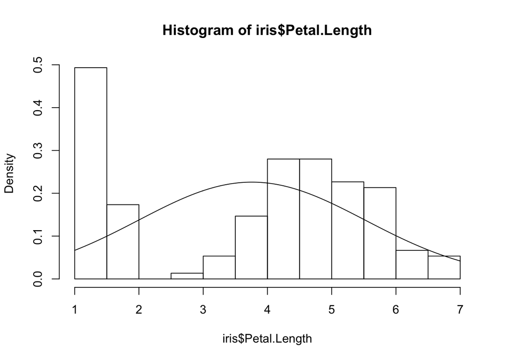

```r
hist(iris$Petal.Length, prob=TRUE)

# generate a sequence over which to evaluate the normal distribution curve
x <- seq(1, 7, 0.01)

# Evaluate the normal distribution density curve function over this range
# with a mean of the data and a standard deviation of the data
y <- dnorm(x, mean=mean(iris$Petal.Length), sd=sd(iris$Petal.Length))

# add this as a line to the plot
lines(y ~ x)
```

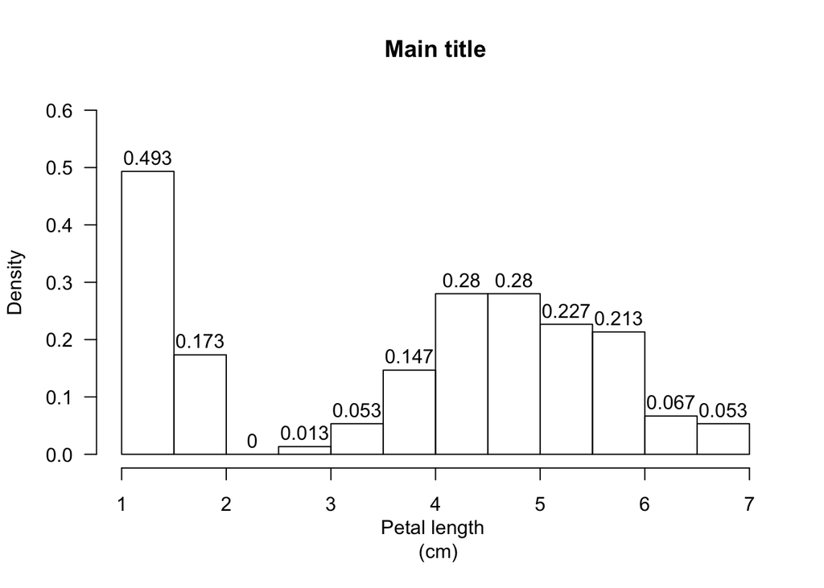

```r
hist(iris$Petal.Length, freq = FALSE, main="Main title",
     xlab="Petal length \n (cm)",
     ylab="Density", las = 1, labels = TRUE, ylim = c(0, 0.6))
```

## 5.9 Adding median and mean to the histogram

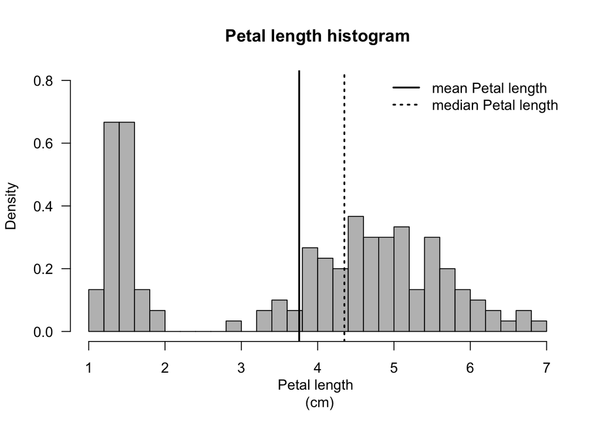

```r
hist(iris$Petal.Length, freq=FALSE, breaks = 30,
     main = "Petal length histogram",
     xlab ="Petal length \n (cm)", ylim=c(0, 0.8),
     las = 1, col = "grey")

# add a vertical line to the figure, using abline(v=...)
# lty = 1 (solid line), lty = 2 (dashed line), lty = 3 (dotted line)
abline(v = c(mean(iris$Petal.Length), median(iris$Petal.Length)),
       lty=c(1, 3), lwd =2)

# add a legend to the topright of the figure
legend("topright", legend=c("mean Petal length", "median Petal length"),
       lty=c(1,3), lwd =2, bty = "n")
```

```r
# print these values to screen for information
mean(iris$Petal.Length)
```

```
## [1] 3.758
```

```r
median(iris$Petal.Length)
```

```
## [1] 4.35
```

## 5.10 Plotting by Species, not all at once

The easiest way to achieve histograms by species (we have three categories in this example), is to extract only the elements which satisfy a defined condition. In this case, `iris$Species == "setosa"` returns `TRUE` where this condition is indeed true, and otherwise returns `FALSE`. When plotting them, R then only plots the elements for which the corresponding values are `TRUE`. This is an essential part of a coder’s repertoire.

```r
# convince ourselves that the conditional statements work as expected.
iris$Species=="setosa"
```

```
##   [1]  TRUE  TRUE  TRUE  TRUE  TRUE  TRUE  TRUE  TRUE  TRUE  TRUE  TRUE
##  [12]  TRUE  TRUE  TRUE  TRUE  TRUE  TRUE  TRUE  TRUE  TRUE  TRUE  TRUE
##  [23]  TRUE  TRUE  TRUE  TRUE  TRUE  TRUE  TRUE  TRUE  TRUE  TRUE  TRUE
##  [34]  TRUE  TRUE  TRUE  TRUE  TRUE  TRUE  TRUE  TRUE  TRUE  TRUE  TRUE
##  [45]  TRUE  TRUE  TRUE  TRUE  TRUE  TRUE FALSE FALSE FALSE FALSE FALSE
##  [56] FALSE FALSE FALSE FALSE FALSE FALSE FALSE FALSE FALSE FALSE FALSE
##  [67] FALSE FALSE FALSE FALSE FALSE FALSE FALSE FALSE FALSE FALSE FALSE
##  [78] FALSE FALSE FALSE FALSE FALSE FALSE FALSE FALSE FALSE FALSE FALSE
##  [89] FALSE FALSE FALSE FALSE FALSE FALSE FALSE FALSE FALSE FALSE FALSE
## [100] FALSE FALSE FALSE FALSE FALSE FALSE FALSE FALSE FALSE FALSE FALSE
## [111] FALSE FALSE FALSE FALSE FALSE FALSE FALSE FALSE FALSE FALSE FALSE
## [122] FALSE FALSE FALSE FALSE FALSE FALSE FALSE FALSE FALSE FALSE FALSE
## [133] FALSE FALSE FALSE FALSE FALSE FALSE FALSE FALSE FALSE FALSE FALSE
## [144] FALSE FALSE FALSE FALSE FALSE FALSE FALSE
```

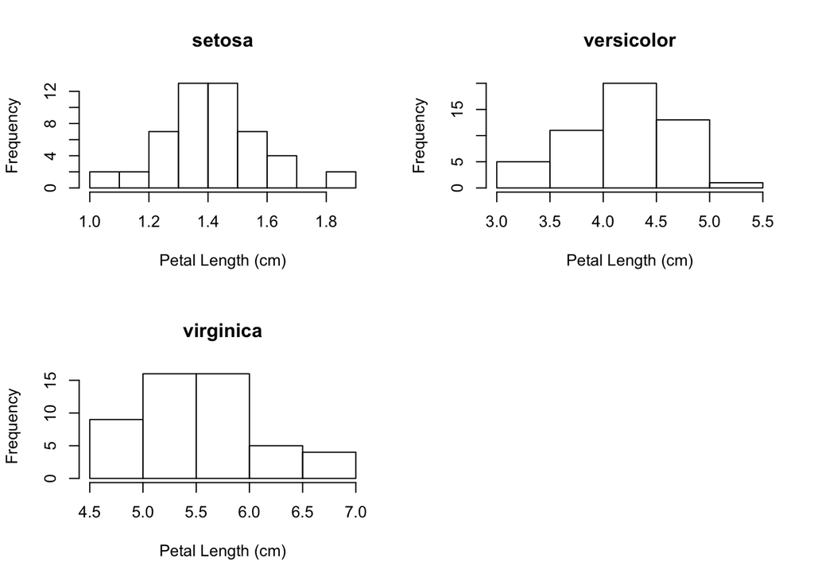

```r
par(mfrow=c(2,2)) # specify a 2x2 panel plot

hist(iris$Petal.Length[iris$Species=="setosa"],  main="setosa",
     xlab="Petal Length (cm)", ylab="Frequency")

hist(iris$Petal.Length[iris$Species=="versicolor"], main="versicolor",
     xlab="Petal Length (cm)", ylab="Frequency")

hist(iris$Petal.Length[iris$Species=="virginica"], main="virginica",
     xlab="Petal Length (cm)", ylab="Frequency")
```

**NOTE** `==` is interpreted as “is it equal to?”, *not* “is equal to”!

THE SAME DATA SHOULD BE PRESENTED LIKE THIS - same x and y axis to compare data distribution between species.

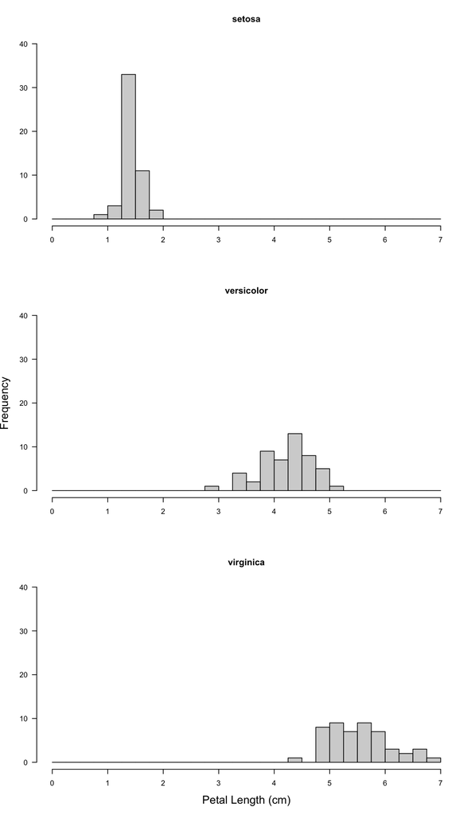

```r
par(mfrow=c(3,1)) # specify a 3x1 panel plot

# Species == setosa
hist(iris$Petal.Length[iris$Species=="setosa"], breaks=seq(0,7,0.25),
      main="setosa", xlab="", ylab="", cex.lab=1.5, ylim=c(0, 40),
     las=1, col="lightgrey")

# Species == versicolor
hist(iris$Petal.Length[iris$Species=="versicolor"], breaks=seq(0,7,0.25),
      main="versicolor", xlab="", ylab="Frequency", ylim=c(0, 40),
     las=1, cex.lab=1.5, col="lightgrey")

# Species == virginica
hist(iris$Petal.Length[iris$Species=="virginica"], breaks=seq(0,7,0.25),
      main="virginica", xlab="Petal Length (cm)", ylab="", ylim=c(0, 40),
     las=1, cex.lab=1.5, col="lightgrey")
```

# 6 Save your histogram

If you want to save your image, you can save it as a image (png, jpeg, tiff, bmp, svg, eps), or pdf or save it to the clipboard as

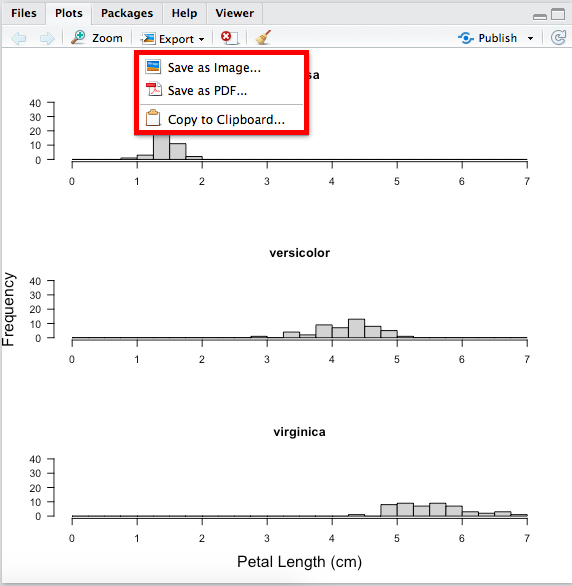

ASSIGNMENT 1:

From the MASS package create four histograms one above the other (use par function) for each litter (A, B, I and J) from the genotype data set. Each histogram should have density function, bins from 30 to 70 divided into length of 10 with labels and y - axis scaling from 0 to 0.2, x -axis label should be weight and colours for Litter A - green, Litter B - blue, Litter I - red and Litter J - brown.